# Final - MEJO 570

Ethan Horton

2023-12-14

# Summary

**Major findings**

**Data basics**

Data available from Wake County’s website (https://data.wake.gov/datasets/ral::reported-crash-locations/explore?location=35.797935%2C-78.624284%2C9.96&showTable=true), the locations, causes and other important data were used to determine the major findings of the analysis. Two data sets — one including the basic details of each crash and one containing coordinates and shapefile multipoints — were joined to provide a single set with both the details and the mapping requirements.

**Detailed findings**

The total number of crashes in the dataset was 205,203, with 65,739 — or 32% — being rear-end crashes. The next two highest categories, respectively, were sideswipes and angled crashes, at 15.1% and 10.3% of the total. Rear-ends made up more than double the second-place sideswipes, and more than second and third combined. Clearly, rear-end crashes were the most common type of crash, by far.

The street name data were jumbled and inconsistent, and it was clear that the RPD did not have a consistent way of marking where crashes occurred other than the exact coordinates. Even the city names were often misspelled, wrong or incoherent. Because of this limitation, it was difficult to group the data by street name and therefore difficult to see if there was a particular road that saw the most rear-end crashes. But, using an interactive map, it was clear that Glenwood Ave., Wade Ave., Capital Blvd. and I-440 were hotspots for rear-end crashes.

Those roads are the major thoroughfares through and around Raleigh — especially for commuters — and it makes sense that they would be prone to rear-ends. Even the timing of the crashes suggests these would be hotspots. The most common times of day for rear-end crashes were during the morning and afternoon rush hours, when roads generally are more congested — especially collector roads and major thoroughfares like I-440 and Wade Ave. The data from rear-ends since Nov. 15, 2023 — about a month’s worth of data up to the point of the download, shows a similar trend of rear-ends occurring on major thoroughfares and collector roads.

Glenwood Ave. had especially bunched results in the last month, centering on major intersections and highway interchanges — again, as expected. There were relatively few in downtown Raleigh, likely because of the low speed and small blocks. In fact, the area inside the Beltline with the most bunched crashes was Western Blvd., near its interchange with I-440.

# Setup

We will be using the following variables:

`crashes` - all crashes and data from Raleigh Police Department from Jan. 1, 2015 through Dec. 11, 2023

`crashes_sf` - shapefile for the crashes in `crashes`, to be joined to `crashes`

`wake-county` - a shapefile of Wake County

`crashes_since_nov_15` - all `crashes` since Nov. 15, 2023

`rear_ends_since_nov_15` - all `crashes_since_nov_15` caused primarily by a rear-end collision

`rear_ends_all_time` - all `crashes` caused primarily by a rear-end collision

`raleigh_travel` - tabular data from the 5-year ACS containing how many commuters drive to work in Raleigh

`types_of_crashes_nov` - `crashes` from Nov. 1 to Dec. 1, 2023, counted by type of crash

`types_of_crashes_oct_nov` - `crashes` from Oct. 1 to Nov. 1, 2023, counted by type of crash, and compared with the crashes from `types_of_crashes_nov`

We will need to load the tidycensus, tidyverse, lubridate, reactable and devtools packages before we get started.

```r
library(tidyverse)
library(tidycensus)
library(lubridate)
library(reactable)
library(devtools)
```

Our data is crash locations and data from Wake County since 2015. Here, we’re loading both datasets (the actual data and the mapping data) in.

```r
crashes <- read_csv("Reported_Crash_Locations.csv",
                    col_types = cols(
                      OBJECTID = col_character(),
                      key_crash = col_integer(),
                      DateOfCrash = col_datetime(
                        format = "%Y/%m/%d %H:%M:%S%z"),
                      UpdateDate = col_datetime(
                        format = "%Y/%m/%d %H:%M:%S%z")
                      )
                    )

crashes_sf <- sf::st_read("Reported_Crash_Locations 2/Reported_Crash_Locations.shp") %>%
  select(key_crash, geometry)
```

Next, even though we don’t particularly need to (since the original, non-selected shapefile also includes most of the data from the original dataset), we’ll join the geography data to the main dataset. To do that, we’ll use a simple left_join().

```r
crashes <- left_join(crashes_sf, crashes, by = "key_crash")
```

There’s some weird time zone inconsistencies going on. Let’s fix that.

```r
crashes$DateOfCrash <- with_tz(crashes$DateOfCrash)
```

# Analysis

Let’s figure out some basics. Is the name for the city location clean?

```r
crashes %>%
  group_by(LocationCity) %>%
  summarise(n()) %>%
  as.data.frame() %>%
  select(-geometry) %>%
  arrange(desc(`n()`))
```

```
##         LocationCity    n()
## 1            RALEIGH 204238
## 2               <NA>    725
## 3               CARY     66
## 4         KNIGHTDALE     36
## 5        WAKE FOREST     27
## 6             GARNER     19
## 7            RALIEGH      9
## 8            RALEGIH      8
## 9             DURHAM      6
## 10            RALEIH      6
## 11            RALEGH      5
## 12           RLAEIGH      4
## 13       MORRISVILLE      3
## 14               RAK      3
```

[output cut: 37 more lines]

Well, clearly not. Names of cities are so all over the place that they’re beyond fixing. How about the cause of the crash?

```r
crashes %>%
  group_by(FirstHarmfulEvent) %>%
  summarise(n()) %>%
  as.data.frame() %>%
  select(-geometry) %>%
  arrange(desc(`n()`))
```

```
##                 FirstHarmfulEvent   n()
## 1          Rear end, slow or stop 65739
## 2       Sideswipe, same direction 31010
## 3                           Angle 21158
## 4            Parked Motor Vehicle 19663
## 5                      Backing up 17763
## 6         Left turn, same roadway  7559
## 7            Ran off road - right  5976
## 8                   Fixed object*  5591
## 9   Left turn, different roadways  5557
## 10            Ran off road - left  4384
## 11  Sideswipe, opposite direction  3302
## 12               Moveable object*  2301
## 13 Right turn, different roadways  2214
## 14       Right turn, same roadway  2185
## 15                     Pedestrian  1790
## 16                         Animal  1587
## 17                        Head on  1505
## 18  Other collision with vehicle*  1491
## 19           Other non-collision*   962
## 20                 Rear end, turn   954
## 21        Ran off road - straight   803
## 22                           <NA>   725
## 23              Overturn/rollover   377
## 24                   Pedalcyclist   355
## 25                        Unknown   175
## 26                      Jackknife    73
## 27               RR train, engine     4
```

This one is helpful! It’s clearly standardized, and definitely something we can use in the analysis. Plus, we now know that 65,739 crashes were rear ends since 2015. Let’s figure out how many there were total, and what percentage of those were rear-ends.

```r
crashes %>%
  as_tibble() %>%
  count() %>%
  mutate(pct_rear_end = ((65739 / n) * 100))
```

```
## # A tibble: 1 × 2
##        n pct_rear_end
##    <int>        <dbl>
## 1 205203         32.0
```

More than 32 percent of all crashes since 2015 were rear ends. That’s a lot. How does it compare to percentages for other crash causes? We know that it’s the highest in rear-ends because of common-sense, but how does it shake out mathematically?

```r
crashes %>%
  as.data.frame() %>%
  count(FirstHarmfulEvent) %>%
  mutate(pct_of_total = ((n / 205203) * 100)) %>%
  arrange(desc(`pct_of_total`))
```

```
##                 FirstHarmfulEvent     n pct_of_total
## 1          Rear end, slow or stop 65739 32.036081344
## 2       Sideswipe, same direction 31010 15.111864836
## 3                           Angle 21158 10.310765437
## 4            Parked Motor Vehicle 19663  9.582218584
## 5                      Backing up 17763  8.656306194
## 6         Left turn, same roadway  7559  3.683669342
## 7            Ran off road - right  5976  2.912238125
## 8                   Fixed object*  5591  2.724619036
## 9   Left turn, different roadways  5557  2.708050077
## 10            Ran off road - left  4384  2.136421007
## 11  Sideswipe, opposite direction  3302  1.609138268
## 12               Moveable object*  2301  1.121328636
## 13 Right turn, different roadways  2214  1.078931595
## 14       Right turn, same roadway  2185  1.064799248
## 15                     Pedestrian  1790  0.872306935
## 16                         Animal  1587  0.773380506
## 17                        Head on  1505  0.733420077
## 18  Other collision with vehicle*  1491  0.726597564
## 19           Other non-collision*   962  0.468804062
## 20                 Rear end, turn   954  0.464905484
## 21        Ran off road - straight   803  0.391319815
## 22                           <NA>   725  0.353308675
## 23              Overturn/rollover   377  0.183720511
## 24                   Pedalcyclist   355  0.172999420
## 25                        Unknown   175  0.085281404
## 26                      Jackknife    73  0.035574529
## 27               RR train, engine     4  0.001949289
```

Yep. More than double. That’s what we thought.

Now, to get a sense of where these crashes — and especially rear-ends — are occurring, we need to load in a map of Wake County.

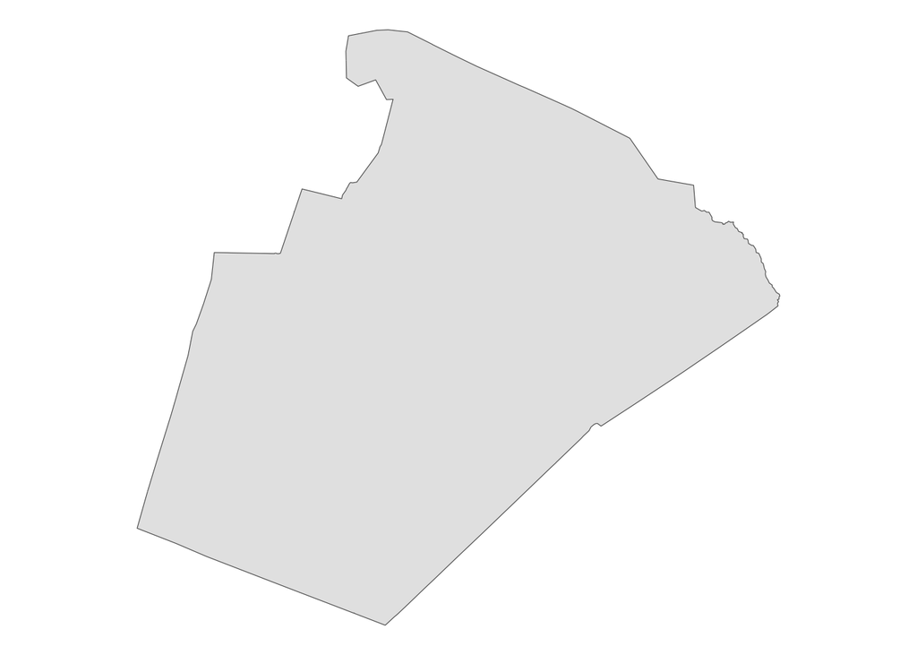

```r
#census_api_key("3ed879379300d12d9cc072fb9b00c9c5e1db3262", install= TRUE, overwrite = TRUE)

wake_county <- get_acs(geography = "county",
              variables = c(population = "B01003_001"),
              # the argument creating a population variable is only used because 'variables' is a required argument
              state = "NC",
              county = "Wake",
              geometry=T)
ggplot() + geom_sf(data = wake_county) +
theme_void()
```

Now, we’ll put a map of our crashes on top of this map of Wake County.

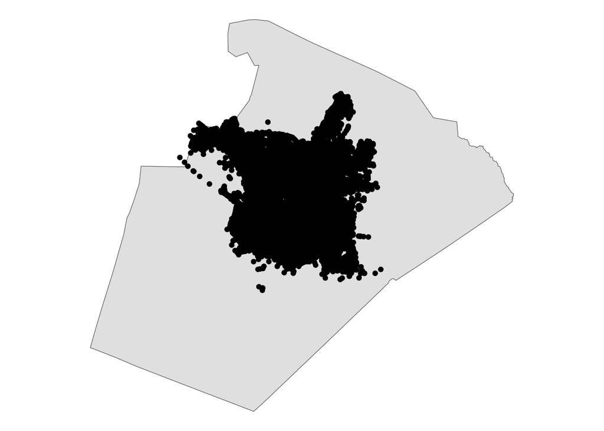

```r
ggplot() + geom_sf(data = wake_county) +
  geom_sf(data = crashes) +
theme_void()
```

The area of crashes makes sense — since this data comes from the City of Raleigh and its police department, it makes sense that the crashes would be centered on Raleigh and not the other municipalities in Wake County.

Now, let’s figure out if there are hotspots for crashes since Nov. 15.

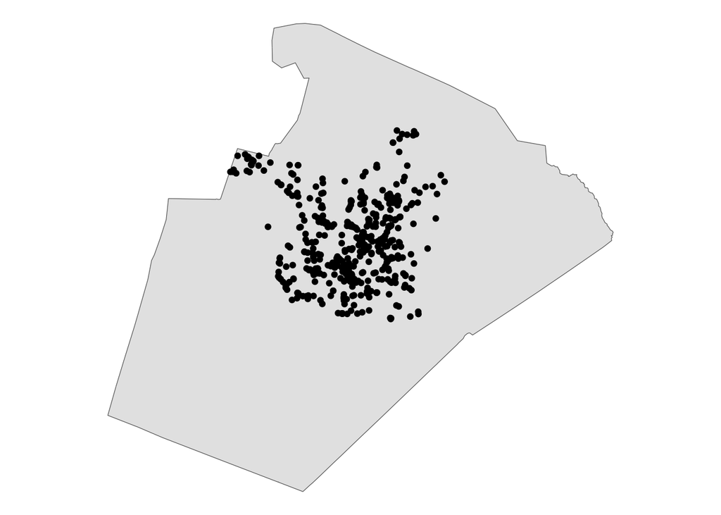

```r
crashes_since_nov_15 <- crashes %>%
  filter(DateOfCrash >= "2023-11-15")

ggplot() + geom_sf(data = wake_county) +
  geom_sf(data = crashes_since_nov_15) +
theme_void()
```

No particular easy-to-read trends there — what about read-ends since Nov. 15?

## Read-ends analysis

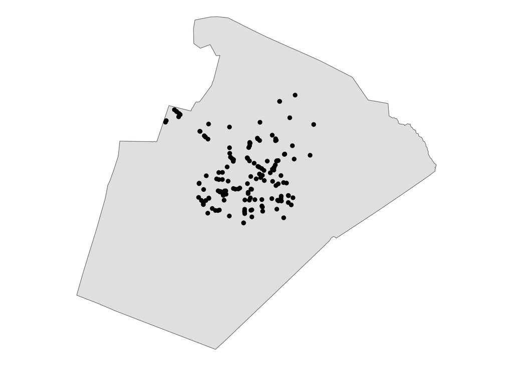

```r
rear_ends_since_nov_15 <- crashes %>%
  filter(DateOfCrash >= "2023-11-15",
         FirstHarmfulEvent == "Rear end, slow or stop")

ggplot() + geom_sf(data = wake_county) +
  geom_sf(data = rear_ends_since_nov_15) +
theme_void()
```

This would be much easier to read with an interactive map.

```r
library(leaflet)

leaflet(data = rear_ends_since_nov_15) %>%
  addTiles() %>%
  setView(lng=-78.680031, lat=35.80, zoom = 10) %>%
  addMarkers(lng = ~LocationLongitude, lat = ~LocationLatitude, popup = "Rear-end crash")
```

[interactive chart not shown]

After zooming in, we can see Glenwood Ave., Wade Ave., Capital Blvd. and I-440 are hotspots for rear end crashes. No particular surprises there.

Is there a relationship with the time of day of the rear end in the last month?

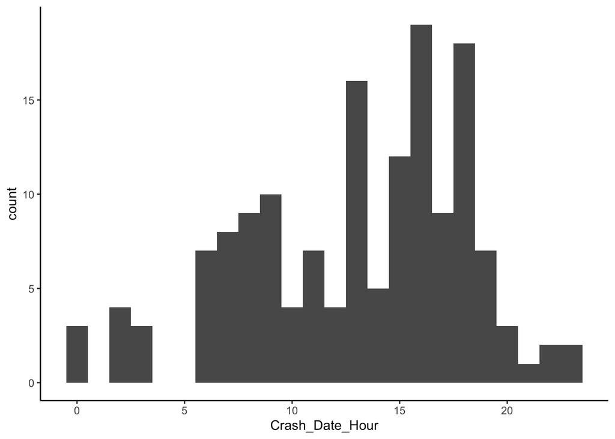

```r
rear_ends_since_nov_15 %>%
  ggplot(aes(Crash_Date_Hour)) + geom_histogram(binwidth = 1) +
  theme_classic()
```

It appears many of the rear-end crashes in Raleigh in the last month have come during rush-hours — the morning rush, just after noon, and between 3 and 7 p.m. What about all-time?

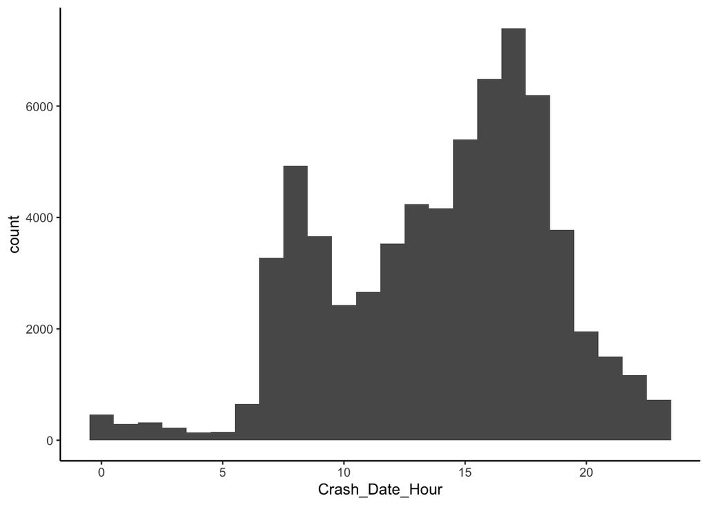

```r
rear_ends_all_time <- crashes %>%
  filter(FirstHarmfulEvent == "Rear end, slow or stop")

rear_ends_all_time %>%
ggplot(aes(Crash_Date_Hour)) + geom_histogram(binwidth = 1) +
  theme_classic()
```

As expected, rush-hours are still the times with the most rear-end crashes all-time. The 8 a.m. hour and the 5 p.m. hour are especially high compared to the hours on either side, which makes sense because of car traffic.

Let’s find out just how many people are traveling to and from work in Raleigh, so we can compare that to the number of crashes.

```r
raleigh_travel <- get_acs(geography = "place",
              variables = c(drivers = "B08301_002"),
              # B08301_002 is the column that shows how many people drive to work each day
              state = "NC",
              geometry=T) %>%
  filter(NAME == "Raleigh city, North Carolina")
print(raleigh_travel$estimate)
```

```
## [1] 193813
```

Nearly 200,000 people drive to work in Raleigh. Let’s find out how many crashes there were by type in November 2023 per 10,000 driving commuters. We’re expecting rear-ends to top the list.

```r
types_of_crashes_nov <- crashes %>%
  filter(DateOfCrash > "2023-11-01",
         DateOfCrash < "2023-12-01") %>%
  count(FirstHarmfulEvent) %>%
  mutate(type_per_10k = ((n / 193813) * 10000)) %>%
  arrange(desc(type_per_10k)) %>%
  as_tibble() %>%
  select(-geometry)

colnames(types_of_crashes_nov) <- c('First Harmful Event', 'Crashes', 'Crashes Per 10k')

types_of_crashes_nov$`Crashes Per 10k` <- signif(types_of_crashes_nov$`Crashes Per 10k`, digits = 4)

# devtools::install_github("glin/reactable")

reactable::reactable(types_of_crashes_nov, filterable = TRUE)
```

| First Harmful Event | Crashes | Crashes Per 10k |
| --- | --- | --- |
| Rear end, slow or stop | 160 | 8.255 |
| Sideswipe, same direction | 85 | 4.386 |
| Angle | 55 | 2.838 |
| Parked Motor Vehicle | 47 | 2.425 |
| Backing up | 30 | 1.548 |
| Left turn, different roadways | 23 | 1.187 |
| Left turn, same roadway | 20 | 1.032 |
| Fixed object* | 15 | 0.7739 |
| Animal | 14 | 0.7223 |
| Ran off road - left | 14 | 0.7223 |

[output cut: 13 more lines]

Again, as expected rear-end crashes were the most common cause of crashes in November 2023. Per 10,000 commuters, there were just over eight rear-ends in November.

And, last, let’s compare November crashes to October crashes, to see if there was a major month-on-month change in crashes per 10,000 commuters.

```r
types_of_crashes_oct_nov <- crashes %>%
  filter(DateOfCrash > "2023-10-01",
         DateOfCrash < "2023-11-01") %>%
  count(FirstHarmfulEvent) %>%
  mutate(type_per_10k = ((n / 193813) * 10000)) %>%
  arrange(desc(type_per_10k)) %>%
  as_tibble() %>%
  select(-geometry)

colnames(types_of_crashes_oct_nov) <- c('First Harmful Event', 'Crashes', 'Oct Per 10k')

types_of_crashes_oct_nov$`Oct Per 10k` <- signif(types_of_crashes_oct_nov$`Oct Per 10k`, digits = 4)

types_of_crashes_oct_nov <- types_of_crashes_oct_nov %>%
  mutate('Nov Per 10k' = types_of_crashes_nov$`Crashes Per 10k`) %>%
  mutate(difference = (types_of_crashes_oct_nov$`Oct Per 10k` - types_of_crashes_nov$`Crashes Per 10k`)) %>%
  mutate(pct_drop = (`difference` / `Oct Per 10k`) * 100) %>%
  select(-Crashes)

types_of_crashes_oct_nov$difference <- signif(types_of_crashes_oct_nov$`difference`, digits = 4)
types_of_crashes_oct_nov$pct_drop <- signif(types_of_crashes_oct_nov$pct_drop, digits = 4)
colnames(types_of_crashes_oct_nov) <- c('First Harmful Event', 'Oct Per 10k', 'Nov Per 10k', 'Difference', 'Percent Drop')

# devtools::install_github("glin/reactable")

reactable::reactable(types_of_crashes_oct_nov, filterable = TRUE)
```

| First Harmful Event | Oct Per 10k | Nov Per 10k | Difference | Percent Drop |
| --- | --- | --- | --- | --- |
| Rear end, slow or stop | 12.13 | 8.255 | 3.875 | 31.95 |
| Sideswipe, same direction | 7.223 | 4.386 | 2.837 | 39.28 |
| Angle | 4.282 | 2.838 | 1.444 | 33.72 |
| Parked Motor Vehicle | 3.405 | 2.425 | 0.98 | 28.78 |
| Backing up | 3.199 | 1.548 | 1.651 | 51.61 |
| Left turn, same roadway | 1.857 | 1.187 | 0.67 | 36.08 |
| Left turn, different roadways | 1.29 | 1.032 | 0.258 | 20 |
| Ran off road - right | 1.032 | 0.7739 | 0.2581 | 25.01 |
| Fixed object* | 0.8771 | 0.7223 | 0.1548 | 17.65 |
| Sideswipe, opposite direction | 0.8255 | 0.7223 | 0.1032 | 12.5 |

[output cut: 13 more lines]

A major difference, indeed. October crashes were much higher than November — almost four rear-ends more per 10,000 commuters.